# Lab 02

Lakhvinder Singh

03.03.2026

# Lab 02: R as a GIS

## Data

The data for this lab can be found in the `./data/CBW/` directory within the course GitHub repository.

Spatial datasets:

1. Streams_Opened_by_Dam_Removal_2012_2017.shp
2. Dam_or_Other_Blockage_Removed_2012_2017.shp
3. County_Boundaries.shp

Non-spatial datasets

1. BMPreport2016_landbmps.csv

## Working with tabular data

```r
# setup
library(tidyverse)
library(sf)
library(tmap)
```

A “join” is a method to join multiple tables together using a matching “key” found in both datasets. For example:

```r
# table of names
t.names <- tibble(key = c(1, 2, 3),
             name = c("Huey", "Dewey", "Louis"))

# table of scores
t.scores <- tibble(name = c("Louis", "Huey", "Dewey"),
                   grade = c(99, 45, 33))

# join them together using a common variable, in this case the "name" variable
t.joined <- left_join(t.names, t.scores, by = "name")
t.joined
```

```
## # A tibble: 3 × 3
##     key name  grade
##   <dbl> <chr> <dbl>
## 1     1 Huey     45
## 2     2 Dewey    33
## 3     3 Louis    99
```

A “left join” finds starts with the table on the “left” and then finds matches in the table on the “right”. See the documentation using `?left_join` for more details and for other types of joins. Sometimes the attributes you’re using to join the tables won’t have the same name, in which case the you need to tell the join function which variables to join on. Note the difference in the `by` argument in the below code block compared to the one above.

```r
t.wonkyNames <- tibble(nombre = c("Dewey", "Louis", "Huey"),
                       x = rep(999),
                       favoriteFood = c("banana", "apple", "carrot"))

t.joined2 <- left_join(t.names, t.wonkyNames, by = c("name" = "nombre"))
t.joined2
```

```
## # A tibble: 3 × 4
##     key name      x favoriteFood
##   <dbl> <chr> <dbl> <chr>
## 1     1 Huey    999 carrot
## 2     2 Dewey   999 banana
## 3     3 Louis   999 apple
```

## Let’s take a look at some tabular data

This dataset includes a list of best management practices (“BMPs”) to reduce nutrient and sediment pollution in the Chesapeake Bay Watershed.

```r
bmps <- read_csv("./CBW/BMPreport2016_landbmps.csv")
glimpse(bmps)
```

```
## Rows: 69,601
## Columns: 18
## $ StateAbbreviation   <chr> "DC", "DC", "DC", "DC", "DC", "DC", "DC", "DC", "D…
## $ GeographyName       <chr> "11001(cbwsonly)", "11001(cbwsonly)", "11001(cbwso…
## $ Geography           <chr> "Washington, DC (CBWS Portion Only)", "Washington,…
## $ Agency              <chr> "Department of Defense", "Department of Defense", …
## $ BMPShortName        <chr> "wetpondwetland", "wetpondwetland", "wetpondwetlan…
## $ BMP                 <chr> "Wet Ponds and Wetlands", "Wet Ponds and Wetlands"…
## $ BMPType             <chr> "Efficiency", "Efficiency", "Efficiency", "Efficie…
## $ Unit                <chr> "Acres Treated", "Acres Treated", "Acres Treated",…
## $ Sector              <chr> "Developed", "Developed", "Developed", "Developed"…
## $ FromLoadSource      <chr> "Non-Regulated Roads", "Non-Regulated Buildings an…
## $ ToLoadSource        <chr> "Non-Regulated Roads", "Non-Regulated Buildings an…
## $ AmountSubmitted     <dbl> 8.709123261, 47.984171150, 1.358309392, 6.76626660…
## $ AmountBackedOut     <dbl> 0, 0, 0, 0, 0, 0, 0, 0, 0, 0, 0, 0, 0, 0, 0, 0, 0,…
## $ AmountNotBackedOut  <dbl> 8.709123261, 47.984171150, 1.358309392, 6.76626660…
## $ AmountCredited      <dbl> 8.709123261, 47.984171150, 1.358309392, 6.76626660…
## $ Excess              <dbl> 0, 0, 0, 0, 0, 0, 0, 0, 0, 0, 0, 0, 0, 0, 0, 0, 0,…
## $ TotalAmountCredited <dbl> 8.709123261, 47.984171150, 1.358309392, 6.76626660…
## $ Cost                <dbl> 11462.077120, 63151.967650, 1787.670991, 8905.0834…
```

Look at the attribute “GeographyName” - it’s a character attribute that contains the counties’ FIPS code, but also some ancillary explanatory data we need to get rid of. There are multiple ways of doing so, including some (very) fancy automated methods that detect patterns of numbers and characters. We’re going to take a simpler approach and assume that all FIPS codes are only 5 characters long.

```r
# edit the bmps variable in place, which isn't always best practices
bmps <- bmps %>% mutate(., FIPS.trimmed = stringr::str_sub(GeographyName, 1, 5))
```

This preparing raw data for further analysis is called “munging”. While the term isn’t the important part, these kinds of preparatory steps can be useful when you’re trying to create “keys” by which to join tables or just clean your tables in general.

Let’s recall how to do some simple tasks

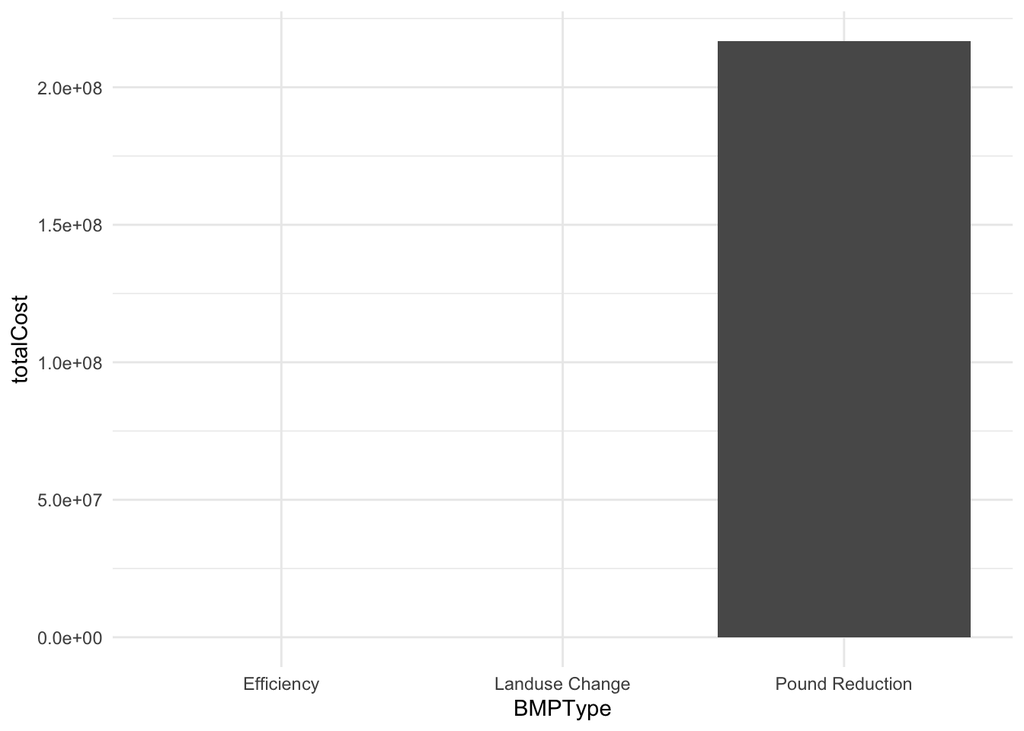

```r
# Let's calculate the total cost by BMP and then plot it
bmps %>% group_by(BMPType) %>% summarise(totalCost = sum(Cost)) %>%
  ggplot(., aes(x = BMPType, y = totalCost)) +
  geom_bar(stat = "identity") +
  theme_minimal()
```

```r
# Doesn't really work. This is because there are missing data in the cost attribute.
# Let's look at it (and this is why we do exploratory data analysis first)

summary(bmps$Cost)
```

```
##     Min.  1st Qu.   Median     Mean  3rd Qu.     Max.     NA's
##        0        0      142    37408     3583 39731974    14286
```

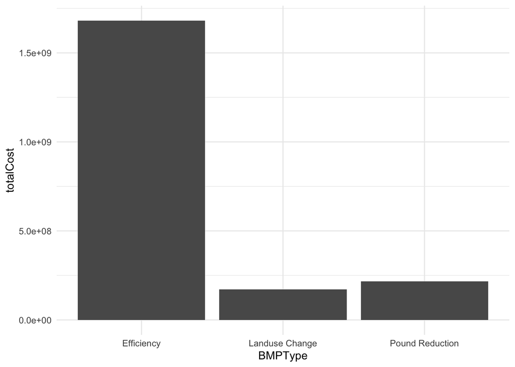

```r
# Yup, lots of "NA's"... We can drop them in our analysis.
# Look carefully at the code in the 'sum' function. What is the na.rm = T parameter doing?


bmps %>% group_by(BMPType) %>% summarise(totalCost = sum(Cost, na.rm = T)) %>%
  ggplot(., aes(x = BMPType, y = totalCost)) +
  geom_bar(stat = "identity") +
  theme_minimal()
```

We can also group by multiple variables at the same time. For example:

```r
# group by state and sector, sum total cost
twofactors <- bmps %>% group_by(StateAbbreviation, Sector) %>%
  summarise(totalCost = sum(Cost))
```

```
## `summarise()` has regrouped the output.
## ℹ Summaries were computed grouped by StateAbbreviation and Sector.
## ℹ Output is grouped by StateAbbreviation.
## ℹ Use `summarise(.groups = "drop_last")` to silence this message.
## ℹ Use `summarise(.by = c(StateAbbreviation, Sector))` for per-operation
##   grouping (`?dplyr::dplyr_by`) instead.
```

```r
twofactors
```

```
## # A tibble: 25 × 3
## # Groups:   StateAbbreviation [7]
##    StateAbbreviation Sector      totalCost
##    <chr>             <chr>           <dbl>
##  1 DC                Developed         NA
##  2 DC                Natural           NA
##  3 DE                Agriculture       NA
##  4 DE                Developed         NA
##  5 DE                Natural           NA
##  6 DE                Septic       2064477.
##  7 MD                Agriculture       NA
##  8 MD                Developed         NA
##  9 MD                Natural           NA
## 10 MD                Septic      50470281.
## # ℹ 15 more rows
```

For our last bit of review, let’s make a few box plots:

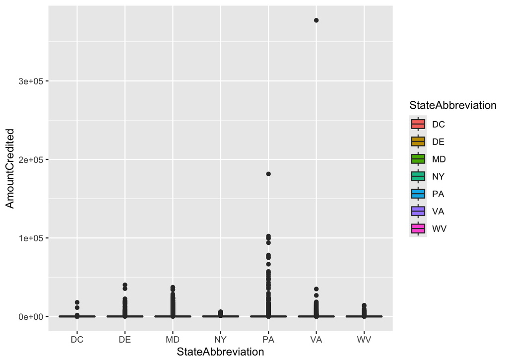

```r
# A simple one
bmps %>% ggplot(., aes(x = StateAbbreviation, y = AmountCredited)) +
  geom_boxplot(aes(fill = StateAbbreviation))
```

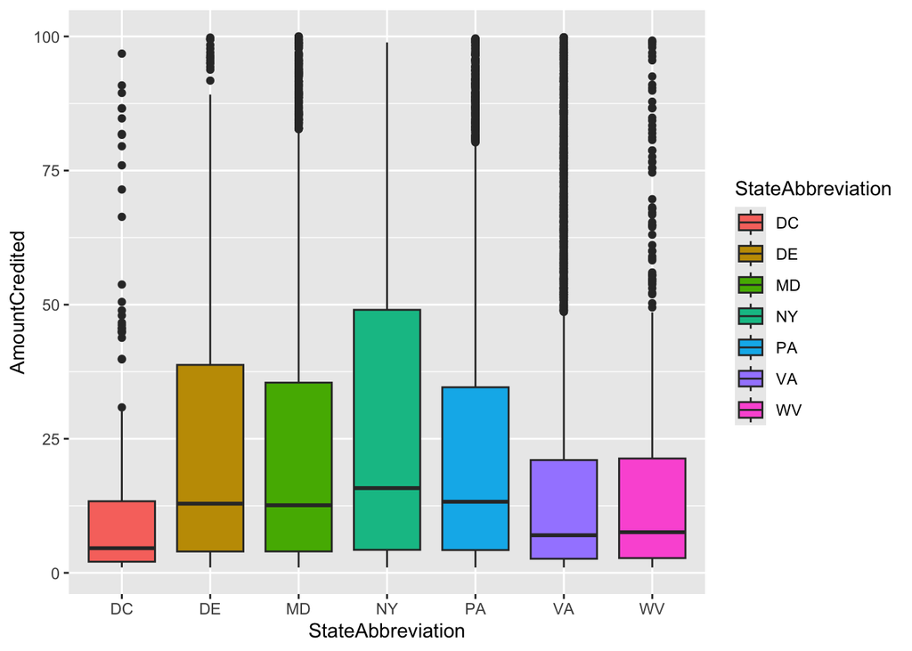

```r
# Very heavily skewed, so just for the sake of visualization,
# let's subset the data (dramatically)
bmps %>%
  dplyr::filter(., AmountCredited > 1 & AmountCredited < 100) %>%
  ggplot(., aes(x = StateAbbreviation, y = AmountCredited)) +
  geom_boxplot(aes(fill = StateAbbreviation))
```

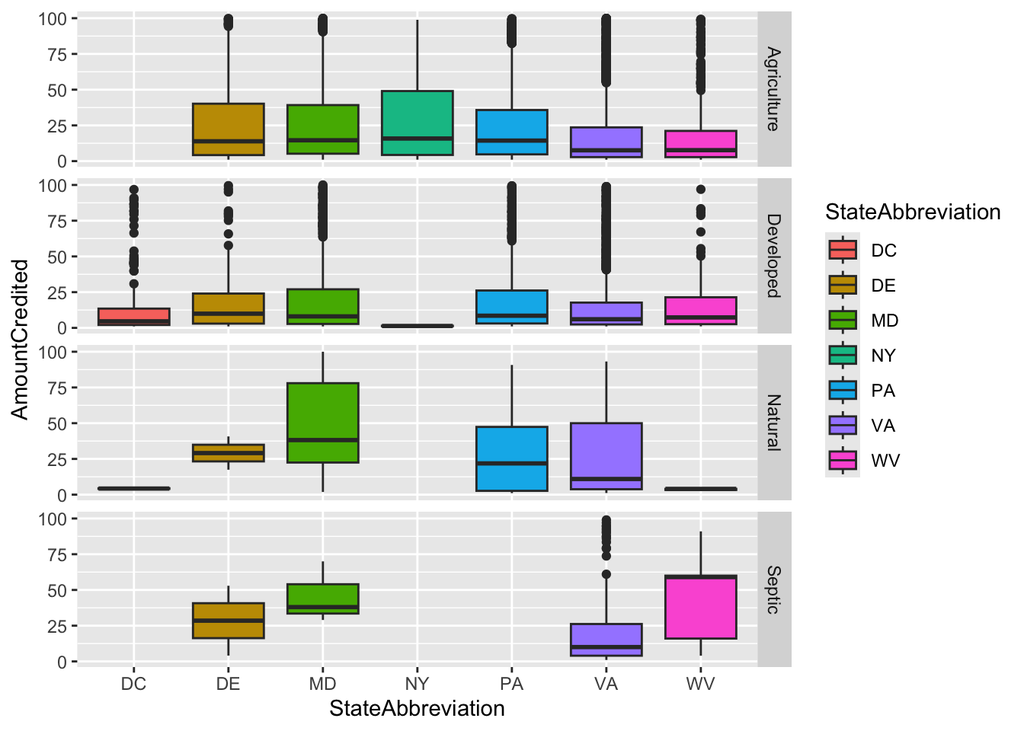

```r
# We can also plot multiple dimensions in our plot using
# the `facet` family of commands in ggplot

bmps %>%
  dplyr::filter(., AmountCredited > 1 & AmountCredited < 100) %>%
  ggplot(., aes(x = StateAbbreviation, y = AmountCredited)) +
  geom_boxplot(aes(fill = StateAbbreviation)) +
  facet_grid(Sector~.)
```

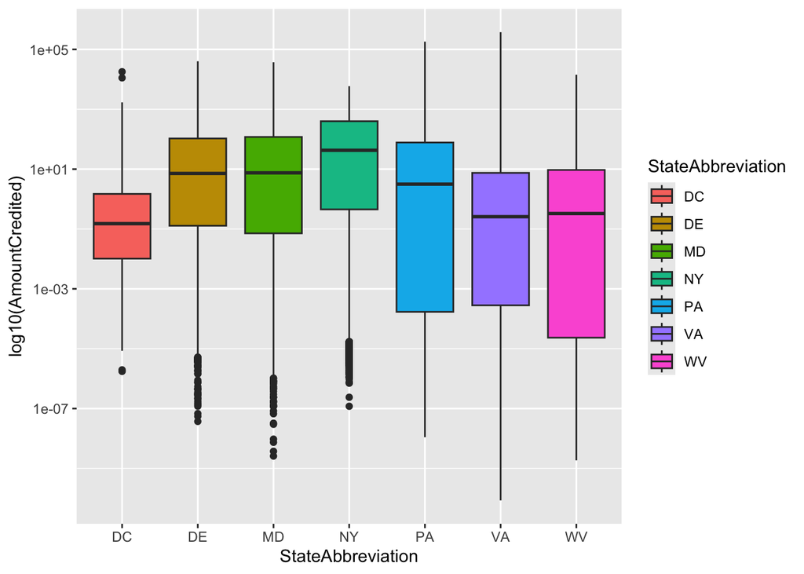

```r
# finally, an alternative to removing the outliers would be to log-transform the y-axis
# But be careful, this removes a lot of the data because the log of 0 is undefined
bmps %>% ggplot(., aes(x = StateAbbreviation, y = AmountCredited)) +
  geom_boxplot(aes(fill = StateAbbreviation)) +
  scale_y_log10() +
  labs(y = "log10(AmountCredited)")
```

The last new item uses the `%in%` command. It’s a way to quickly figure out which elements are inside of another. In that sense, it’s similar to a spatial intersection, but for other types of data.

```r
# setup a demonstration vector
x <- c(1, 2, 3, 4, 5)

# is 7 in our vector?
7 %in% x # should evaluate False
```

```
## [1] FALSE
```

```r
2 %in% x # should evaluate True
```

```
## [1] TRUE
```

```r
# can also do it with vectors
c(4, 99, 1) %in% x
```

```
## [1]  TRUE FALSE  TRUE
```

Lastly, let’s recall using tmap on our data. Also remember you can use `sf::st_make_valid` to fix offending geometry

```r
counties <- sf::read_sf("./CBW/County_Boundaries.shp")
counties %>% sf::st_is_valid()
```

```
##   [1]  TRUE  TRUE  TRUE  TRUE  TRUE  TRUE  TRUE  TRUE  TRUE  TRUE  TRUE  TRUE
##  [13]  TRUE  TRUE  TRUE  TRUE  TRUE  TRUE  TRUE  TRUE  TRUE  TRUE  TRUE  TRUE
##  [25]  TRUE  TRUE  TRUE  TRUE  TRUE  TRUE  TRUE  TRUE  TRUE  TRUE  TRUE  TRUE
##  [37]  TRUE  TRUE  TRUE  TRUE  TRUE  TRUE  TRUE  TRUE  TRUE  TRUE  TRUE  TRUE
##  [49]  TRUE  TRUE  TRUE  TRUE  TRUE  TRUE  TRUE  TRUE  TRUE  TRUE  TRUE  TRUE
##  [61]  TRUE  TRUE  TRUE  TRUE  TRUE  TRUE  TRUE  TRUE  TRUE  TRUE  TRUE  TRUE
##  [73]  TRUE  TRUE  TRUE  TRUE  TRUE  TRUE  TRUE  TRUE  TRUE  TRUE  TRUE  TRUE
##  [85]  TRUE  TRUE  TRUE  TRUE  TRUE  TRUE  TRUE  TRUE  TRUE  TRUE  TRUE  TRUE
##  [97]  TRUE  TRUE  TRUE  TRUE  TRUE  TRUE  TRUE  TRUE  TRUE  TRUE  TRUE  TRUE
## [109]  TRUE  TRUE  TRUE  TRUE  TRUE  TRUE  TRUE  TRUE  TRUE  TRUE  TRUE  TRUE
## [121]  TRUE  TRUE  TRUE  TRUE  TRUE  TRUE  TRUE  TRUE  TRUE  TRUE  TRUE  TRUE
## [133]  TRUE  TRUE  TRUE  TRUE  TRUE  TRUE  TRUE  TRUE  TRUE  TRUE  TRUE  TRUE
## [145]  TRUE  TRUE  TRUE  TRUE  TRUE  TRUE  TRUE  TRUE  TRUE  TRUE  TRUE  TRUE
## [157]  TRUE  TRUE  TRUE  TRUE  TRUE  TRUE  TRUE  TRUE  TRUE  TRUE  TRUE  TRUE
## [169]  TRUE  TRUE  TRUE  TRUE  TRUE  TRUE  TRUE  TRUE  TRUE  TRUE  TRUE  TRUE
## [181]  TRUE  TRUE  TRUE  TRUE  TRUE  TRUE  TRUE  TRUE  TRUE  TRUE  TRUE  TRUE
## [193]  TRUE  TRUE  TRUE  TRUE  TRUE  TRUE  TRUE  TRUE  TRUE  TRUE  TRUE  TRUE
## [205]  TRUE FALSE  TRUE
```

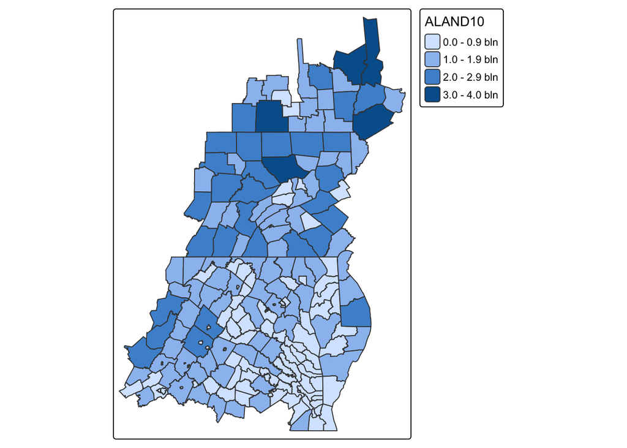

```r
counties <- counties %>% sf::st_make_valid()

# quick map of the data
tm_shape(counties) + tm_polygons(fill = "ALAND10")
```

## Your tasks

Using the following data…

```r
# spatial
# Note, the st_make_valid() calls are NOT necessary in all cases
# But we know it's needed for the counties, and doesn't really hurt anything
# for the others
counties <- sf::read_sf("./CBW/County_Boundaries.shp") %>%
  sf::st_make_valid()
dams <- sf::read_sf("./CBW/Dam_or_Other_Blockage_Removed_2012_2017.shp") %>%
  sf::st_make_valid()
streams <- sf::read_sf("./CBW/Streams_Opened_by_Dam_Removal_2012_2017.shp") %>%
  sf::st_make_valid()

# aspatial
bmps <- read_csv("./CBW/BMPreport2016_landbmps.csv")
```

…complete the following tasks.

Complete each task COMPLETELY USING R CODE. YOU MUST SHOW YOUR WORK FOR EACH ANSWER. Label your variables sensibly and use comments such that I can find your answers and your work. The following tasks draw upon lecture, your assigned readings, and the examples shown above. As always, there are multiple ways of completing each task. Remember, it’s always a good idea to perform some exploratory data analysis on your own prior to starting work.

### Task 1: Aspatial operations

```r
#1.1 Calculate summary statistics for the Cost of BMPs for each State (including DC)
# na.rm = True removes missing values so math works. Cheers.
bmp_cost_summary <- bmps %>%
  group_by(StateAbbreviation) %>%
  summarise(
    mean_cost = mean(Cost, na.rm = TRUE),
    median_cost = median(Cost, na.rm = TRUE),
    sd_cost = sd(Cost, na.rm = TRUE),
    min_cost = min(Cost, na.rm = TRUE),
    max_cost = max(Cost, na.rm = TRUE)
  )

bmp_cost_summary
```

```
## # A tibble: 7 × 6
##   StateAbbreviation mean_cost median_cost sd_cost min_cost  max_cost
##   <chr>                 <dbl>       <dbl>   <dbl>    <dbl>     <dbl>
## 1 DC                   22193.       629.  106690.   0.0510  1891064.
## 2 DE                   30682.       906.  173938.   0       5041838.
## 3 MD                   53118.       876.  356888.   0      12086857.
## 4 NY                    8129.      1954.   27789.   0        622138.
## 5 PA                   59904.       431.  473775.   0      19968186
## 6 VA                   25380.        15.2 348963.   0      39731974.
## 7 WV                   50014.        96.8 521885.   0      15796521.
```

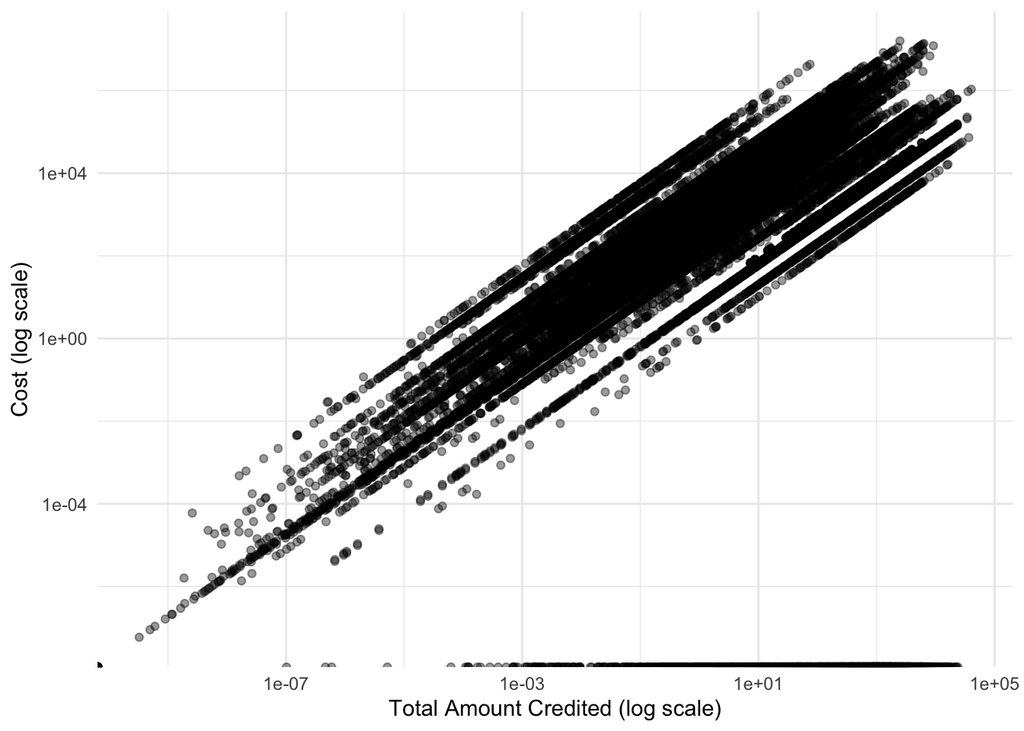

```r
#1.2 Make a scatterplot of Cost vs. TotalAmountCredited, ONLY FOR BMPs with `Units` of type "Acres". You may need to apply a data transformation to one or more axes if the data are heavily skewed.

# Need to Keep only BMPs measured in Acres, also we are applying log scales to reduce the effect of extreme values. theme minimal is used to make plot look clean.
bmps %>%
  filter(str_detect(Unit, "Acres")) %>%
  ggplot(aes(x = TotalAmountCredited, y = Cost)) +
  geom_point(alpha = 0.4) +
  scale_x_log10() +
  scale_y_log10() +
  labs(
    x = "Total Amount Credited (log scale)",
    y = "Cost (log scale)"
  ) +
  theme_minimal()
```

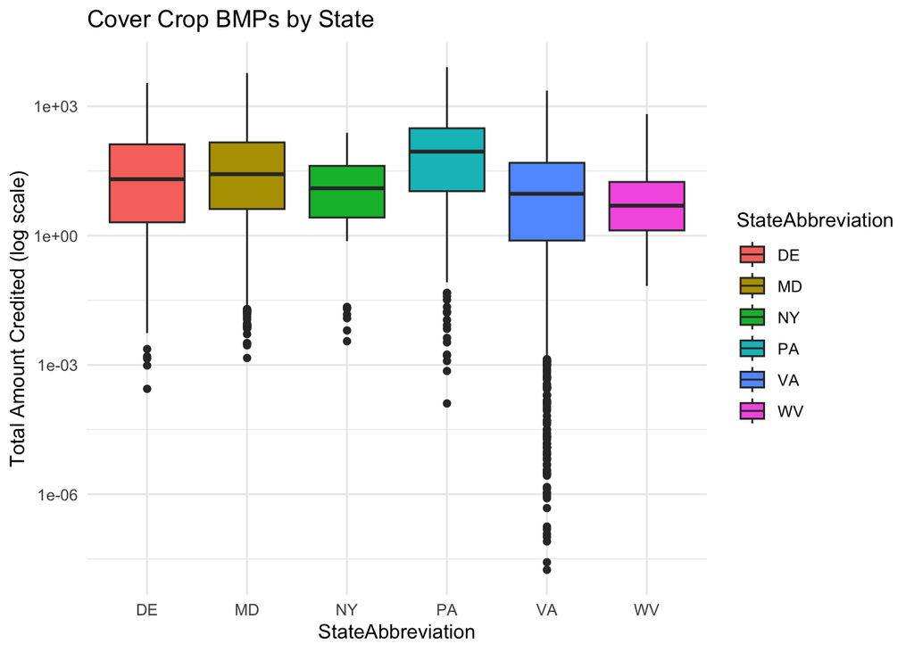

````r
#1.3 Make a boxplot with "StateAbbreviation" on the x-axis and "TotalAmountCredited" on the y-axis. HOWEVER, the only data I want plotted are for cover crop BMPs. Note, there are many types of cover crops in this dataset, and I want you to include them ALL. There are handy functions within the ```stringr``` package that can help you here. Use the help function ```?stringr``` or read the documentations/vignettes found online. A Google search for "r stringr vignettes documentation" would be a good place to start if you're having trouble.

# str_detect() can be applied to find all BMPS that include "COVER WORD"
cover_crop_bmps <- bmps %>%
  filter(str_detect(str_to_lower(BMP), "cover"))

# Boxplot by state
ggplot(cover_crop_bmps,
       aes(x = StateAbbreviation, y = TotalAmountCredited)) +
  geom_boxplot(aes(fill = StateAbbreviation)) +
  scale_y_log10() +
  labs(
    y = "Total Amount Credited (log scale)",
    title = "Cover Crop BMPs by State"
  ) +
  theme_minimal()
````

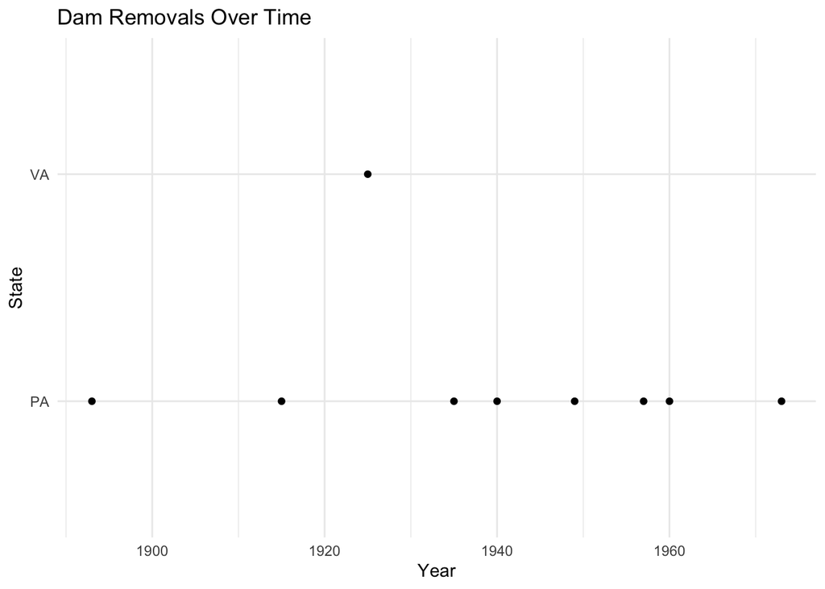

```r
#1.4 make a scatterplot of the `dam` dataset, this time with "YEAR" on the x-axis and "STATE" on y-axis (think of it like a timeline). Assume no dams were built in year 0, so you'll need to remove those data points. You know how to remove observations based on a given criteria.

# Removed data points assuming no dams built before year 0 by using filter (YEAR > 0)
dams %>%
  filter(YEAR > 0) %>%
  ggplot(aes(x = YEAR, y = STATE)) +
  geom_point() +
  labs(
    x = "Year",
    y = "State",
    title = "Dam Removals Over Time"
  ) +
  theme_minimal()
```

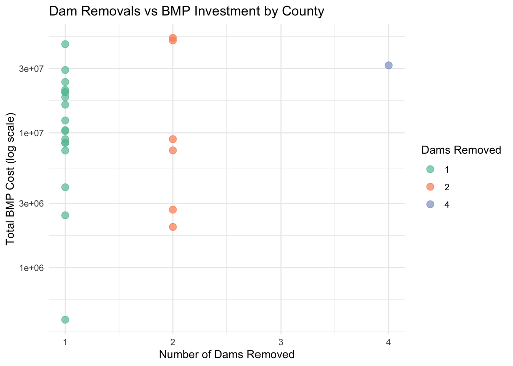

```r
#1.5 make one last (aspatial) visualization. But this time, it's your choice what data and plots to use. The only requirement is that you link two of the datasets together in some manner. Be creative. Make it look nice (e.g., use proper labels, interesting colors/shading/size).

library(tidyverse)
library(sf)

# Read data
counties <- read_sf("./CBW/County_Boundaries.shp") %>%
  st_make_valid()

dams <- read_sf("./CBW/Dam_or_Other_Blockage_Removed_2012_2017.shp") %>%
  st_make_valid()

bmps <- read_csv("./CBW/BMPreport2016_landbmps.csv") %>%
  mutate(FIPS = str_sub(GeographyName, 1, 5))
# Count dams per county (USE GEOID10) , dam_n means no of dams removed in a county
dams_cty <- st_join(dams, counties) %>%
  group_by(GEOID10) %>%
  summarise(dam_n = n(), .groups = "drop")

# Sum BMP cost per county (USE FIPS)
bmp_cty <- bmps %>%
  group_by(FIPS) %>%
  summarise(bmp_cost = sum(Cost, na.rm = TRUE))

# Joining both summaries
cty_join <- left_join(dams_cty, bmp_cty,
                      by = c("GEOID10" = "FIPS"))

# Scatter plot
ggplot(cty_join, aes(dam_n, bmp_cost, color = factor(dam_n))) +
  geom_point(size = 3, alpha = 0.7) +
  scale_color_brewer(palette = "Set2") +
  scale_y_log10() +
  labs(
    x = "Number of Dams Removed",
    y = "Total BMP Cost (log scale)",
    color = "Dams Removed",
    title = "Dam Removals vs BMP Investment by County"
  ) +
  theme_minimal()
```